# Reference Genomes

2020-12-13

## Objectives

- Understand what a reference genome is and what it contains.
- Understand the FASTA and GTF formats.
- Appreciate the differences in gene identifiers.
- Understand how to download a reference genome.

## Differential Expression Workflow

| Step | Task |
| --- | --- |
| 1 | Experimental Design |
| 2 | Biological Samples / Library Preparation |
| 3 | Sequence Reads |
| 4 | Assess Quality of Raw Reads |
| **5** | **Splice-aware Mapping to Genome** |
| **6** | **Count Reads Associated with Genes** |
| 7 | Test for DE Genes |

## Reference Genomes

- A reference genome consists of:
  - Reference sequence and,
  - Genomic annotations that describe attributes about that sequence.
- Examples of annotations include:
  - Gene models, the location and other information about genes.
  - Variants, location of common or rare genetic variants, their alleles, and frequencies.
  - Small RNAs, location and other information about various types of small RNAs.
- For our analysis we need the reference sequence and gene models.

## Reference Sequence

- Stored in [FASTA](https://en.wikipedia.org/wiki/FASTA_format) format.

```
>chrM
GATCACAGGTCTATCACCCTATTAACCACTCACGGGAGCTCTCCATGCAT
TTGGTATTTTCGTCTGGGGGGTGTGCACGCGATAGCATTGCGAGACGCTG
GAGCCGGAGCACCCTATGTCGCAGTATCTGTCTTTGATTCCTGCCTCATT
CTATTATTTATCGCACCTACGTTCAATATTACAGGCGAACATACCTACTA
AAGTGTGTTAATTAATTAATGCTTGTAGGACATAATAATAACAATTGAAT
GTCTGCACAGCCGCTTTCCACACAGACATCATAACAAAAAATTTCCACCA
AACCCCCCCCTCCCCCCGCTTCTGGCCACAGCACTTAAACACATCTCTGC
CAAACCCCAAAAACAAAGAACCCTAACACCAGCCTAACCAGATTTCAAAT
TTTATCTTTAGGCGGTATGCACTTTTAACAGTCACCCCCCAACTAACACA
```

## Gene Models

- Example `workshop_data/human_reference/hg19/hg19_genes.gtf`:

```
chr1    unknown exon    11874   12227   .   +   .   gene_id "DDX11L1"; gene_name "DDX11L1"; transcript_id "NR_046018"; tss_id "TSS16932";
chr1    unknown exon    12613   12721   .   +   .   gene_id "DDX11L1"; gene_name "DDX11L1"; transcript_id "NR_046018"; tss_id "TSS16932";
chr1    unknown exon    13221   14409   .   +   .   gene_id "DDX11L1"; gene_name "DDX11L1"; transcript_id "NR_046018"; tss_id "TSS16932";
chr1    unknown exon    14362   14829   .   -   .   gene_id "WASH7P"; gene_name "WASH7P"; transcript_id "NR_024540"; tss_id "TSS8568";
```

- Example `workshop_data/human_reference/GRCh38/GRCh38.98.gtf`:

```
1   havana  gene    11869   14409   .   +   .   gene_id "ENSG00000223972"; gene_version "5"; gene_name "DDX11L1"; gene_source "havana"; gene_biotype "transcribed_unprocessed_pseudogene";
1   havana  transcript  11869   14409   .   +   .   gene_id "ENSG00000223972"; gene_version "5"; transcript_id "ENST00000456328"; transcript_version "2"; gene_name "DDX11L1"; gene_source "havana"; gene_biotype "transcribed_unprocessed_pseudogene"; transcript_name "DDX11L1-202"; transcript_source "havana"; transcript_biotype "lncRNA"; tag "basic"; transcript_support_level "1";
1   havana  exon    11869   12227   .   +   .   gene_id "ENSG00000223972"; gene_version "5"; transcript_id "ENST00000456328"; transcript_version "2"; exon_number "1"; gene_name "DDX11L1"; gene_source "havana"; gene_biotype "transcribed_unprocessed_pseudogene"; transcript_name "DDX11L1-202"; transcript_source "havana"; transcript_biotype "lncRNA"; exon_id "ENSE00002234944"; exon_version "1"; tag "basic"; transcript_support_level "1";
```

## GTF Format

1. Chromsome
2. Source, e.g. ensembl, havana
3. Gene feature, e.g. exon, intron, mRNA, transcript
4. Start location, 1-based
5. End location, 1-based
6. Score
7. Strand
8. Frame, relating to codons
9. Attribute, a semicolon separated list of key/value pairs giving additional information about the feature

## Genome Builds

- New reference genomes are versioned.
  - e.g. UCSC genomes hg18, hg19, hg38
  - e.g. ENSEMBL genomes GRCh36, GRCh37, GRCh38
- With the most recent genome build, versioning is aligned.

## Annotation Sources

- Historically three primary human gene annotation databases (different organisms have their own databases):
  - [NCBI RefSeq](https://www.ncbi.nlm.nih.gov/refseq/rsg/)
  - [ENSEMBL](https://www.ensembl.org/info/genome/genebuild/index.html)
  - [UCSC Known Genes](https://academic.oup.com/bioinformatics/article/22/9/1036/200093)
- We will skip what each emphasizes, but note [others have examined this](https://bmcgenomics.biomedcentral.com/articles/10.1186/s12864-015-1308-8).

## Gene IDs

- The two GTFs that we looked at illustrated some differences between the gene annotation databases.
- First GTF:
  - Chromosomes are “chr1”
  - DDX11L1, the gene symbol, controlled by the [Human Gene Nomenclature Committee (HUGO)](https://www.genenames.org/)
  - NR_046018, the RefSeq transcript ID
- Second GTF:
  - Chromosomes are “1”
  - ENSG00000223972, the ENSEMBL gene ID
  - DDX11L1, the gene symbol, thankfully the same
  - ENST00000456328, the ENSEMBL transcript ID

## Getting a Reference Genome

- [Illumina iGenomes](https://support.illumina.com/sequencing/sequencing_software/igenome.html)
  - Easy
  - Comprehensive
  - Includes reference sequence and gene models (and sometimes more).
- **Note**, reference genomes can be very large. Typically not downloaded to your personal computer.

## Getting a Reference Genome

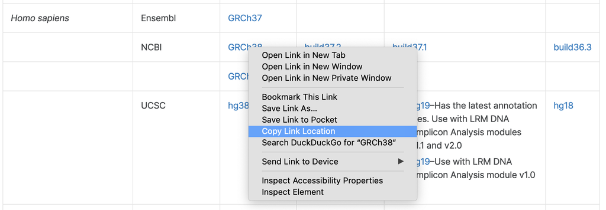

## Getting a Reference Genome

- On Great Lakes or on your lab’s server:

```
$ wget <url from previous slide>
$ tar -xf <resulting file>
```

## Which Reference is Right for Me?

- Be consistent in your research. Pick one and use it.
  - Switching between sources will cause headaches for mapping gene IDs.
- Do not mix UCSC and ENSEMBL.
  - “chr1” and “1” chromosome references will cause issues.

These materials have been adapted and extended from materials created by the [Harvard Chan Bioinformatics Core (HBC)](http://bioinformatics.sph.harvard.edu/). These are open access materials distributed under the terms of the [Creative Commons Attribution license (CC BY 4.0)](http://creativecommons.org/licenses/by/4.0/), which permits unrestricted use, distribution, and reproduction in any medium, provided the original author and source are credited.